# EasyVisa

Importing Libraries

```python
# to manipulate data
import pandas as pd
import numpy as np

# to visualize data
%matplotlib inline
import matplotlib.pyplot as plt

import seaborn as sns

import warnings
warnings.filterwarnings("ignore")
```

Loading Dataset

```python
df=pd.read_csv('EasyVisa.csv.zip')
```

Data Overview

```python
df.head()
```

|  | case_id | continent | education_of_employee | has_job_experience | requires_job_training | no_of_employees | yr_of_estab | region_of_employment | prevailing_wage | unit_of_wage | full_time_position | case_status |
| --- | --- | --- | --- | --- | --- | --- | --- | --- | --- | --- | --- | --- |
| 0 | EZYV01 | Asia | High School | N | N | 14513 | 2007 | West | 592.2029 | Hour | Y | Denied |
| 1 | EZYV02 | Asia | Master's | Y | N | 2412 | 2002 | Northeast | 83425.6500 | Year | Y | Certified |
| 2 | EZYV03 | Asia | Bachelor's | N | Y | 44444 | 2008 | West | 122996.8600 | Year | Y | Denied |
| 3 | EZYV04 | Asia | Bachelor's | N | N | 98 | 1897 | West | 83434.0300 | Year | Y | Denied |
| 4 | EZYV05 | Africa | Master's | Y | N | 1082 | 2005 | South | 149907.3900 | Year | Y | Certified |

```python
df.shape
```

```
(25480, 12)
```

```python
df.info()
```

```
<class 'pandas.core.frame.DataFrame'>
RangeIndex: 25480 entries, 0 to 25479
Data columns (total 12 columns):
 #   Column                 Non-Null Count  Dtype
---  ------                 --------------  -----
 0   case_id                25480 non-null  object
 1   continent              25480 non-null  object
 2   education_of_employee  25480 non-null  object
 3   has_job_experience     25480 non-null  object
 4   requires_job_training  25480 non-null  object
 5   no_of_employees        25480 non-null  int64
 6   yr_of_estab            25480 non-null  int64
 7   region_of_employment   25480 non-null  object
 8   prevailing_wage        25480 non-null  float64
 9   unit_of_wage           25480 non-null  object
 10  full_time_position     25480 non-null  object
 11  case_status            25480 non-null  object
dtypes: float64(1), int64(2), object(9)
memory usage: 2.3+ MB
```

observations: .The dataset contains 25480 entries and 11 features. .The dataset consists of 3 numerical columns, 9 categorical columns. .The target varibale is case_status.

```python
df.describe()
```

|  | no_of_employees | yr_of_estab | prevailing_wage |
| --- | --- | --- | --- |
| count | 25480.000000 | 25480.000000 | 25480.000000 |
| mean | 5667.043210 | 1979.409929 | 74455.814592 |
| std | 22877.928848 | 42.366929 | 52815.942327 |
| min | -26.000000 | 1800.000000 | 2.136700 |
| 25% | 1022.000000 | 1976.000000 | 34015.480000 |
| 50% | 2109.000000 | 1997.000000 | 70308.210000 |
| 75% | 3504.000000 | 2005.000000 | 107735.512500 |
| max | 602069.000000 | 2016.000000 | 319210.270000 |

Observations: .The no of employees has a mean of 5,667 and median of 2,109. This indicates that the distribution is skewed. .The minimum number of employees are -26 which could be a error. .prevailing wage ranges from 2 to 319,210 and distribution is skewed. .year of establishment ranges from 1800 to 2016

```python
df.describe(include='object').T
```

|  | count | unique | top | freq |
| --- | --- | --- | --- | --- |
| case_id | 25480 | 25480 | EZYV25480 | 1 |
| continent | 25480 | 6 | Asia | 16861 |
| education_of_employee | 25480 | 4 | Bachelor's | 10234 |
| has_job_experience | 25480 | 2 | Y | 14802 |
| requires_job_training | 25480 | 2 | N | 22525 |
| region_of_employment | 25480 | 5 | Northeast | 7195 |
| unit_of_wage | 25480 | 4 | Year | 22962 |
| full_time_position | 25480 | 2 | Y | 22773 |
| case_status | 25480 | 2 | Certified | 17018 |

Exploratory Data Analysis

```python
df.isna().sum()
```

```
case_id                  0
continent                0
education_of_employee    0
has_job_experience       0
requires_job_training    0
no_of_employees          0
yr_of_estab              0
region_of_employment     0
prevailing_wage          0
unit_of_wage             0
full_time_position       0
case_status              0
dtype: int64
```

observations:No null values in dataset

```python
df.duplicated().sum()
```

```
np.int64(0)
```

observations:No duplicate entries observed in dataset

```python
#handling the negative values in no of employees
df[df['no_of_employees']<0].shape
```

```
(33, 12)
```

There are 33 such values which have negative number of employess,conerting those negative to positive using abs function

```python
df['no_of_employees']=abs(df['no_of_employees'])
```

```python
df[df['no_of_employees']<0].shape
```

```
(0, 12)
```

```python
#dropping the case_id as it has only unique values which is not needed
df.drop('case_id',axis=1,inplace=True)
```

Univariate Analysis

```python
def countplot(cols):
    # Print value counts
    print(df[cols].value_counts(normalize=True) * 100)

    # Set figure size
    plt.figure(figsize=(8, 6))  # You can adjust these dimensions as needed

    # Create countplot
    ax = sns.countplot(x=cols, data=df)

    # Get total number of data points in the column
    total = len(df[cols])

    # Annotate percentage values on the plot
    for p in ax.patches:
        label = "{:.1f}%".format(100 * p.get_height() / total)

        # Position the text on the bar
        x = p.get_x() + p.get_width() / 2
        y = p.get_height()

        ax.annotate(
            label,
            (x, y),
            ha="center",
            va="center",
            size=10,
            xytext=(0, 5),
            textcoords="offset points"
        )
    # Show plot
    plt.show()
```

```
continent
Asia             66.173469
Europe           14.646782
North America    12.919937
South America     3.343799
Africa            2.162480
Oceania           0.753532
Name: proportion, dtype: float64
```

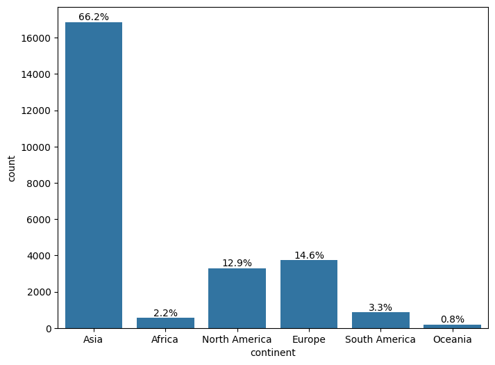

```python
countplot('continent')
```

```
education_of_employee
Bachelor's     40.164835
Master's       37.810047
High School    13.422292
Doctorate       8.602826
Name: proportion, dtype: float64
```

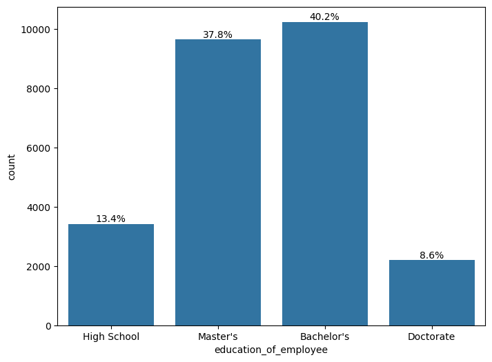

```python
countplot('education_of_employee')
```

```
has_job_experience
Y    58.092622
N    41.907378
Name: proportion, dtype: float64
```

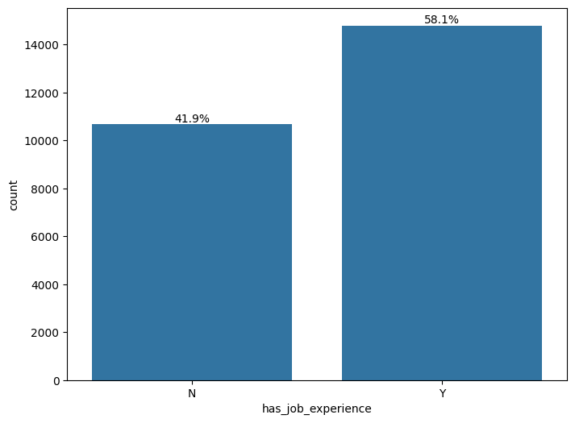

```python
countplot('has_job_experience')
```

```
requires_job_training
N    88.402669
Y    11.597331
Name: proportion, dtype: float64
```

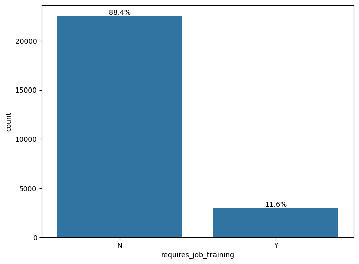

```python
countplot('requires_job_training')
```

```
region_of_employment
Northeast    28.237834
South        27.539246
West         25.847724
Midwest      16.903454
Island        1.471743
Name: proportion, dtype: float64
```

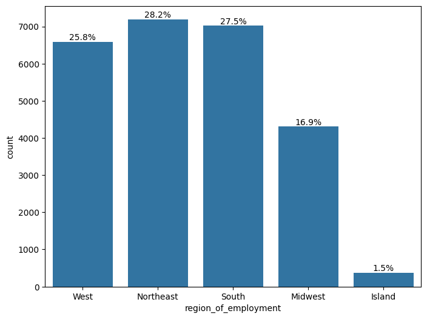

```python
countplot('region_of_employment')
```

```
case_status
Certified    66.789639
Denied       33.210361
Name: proportion, dtype: float64
```

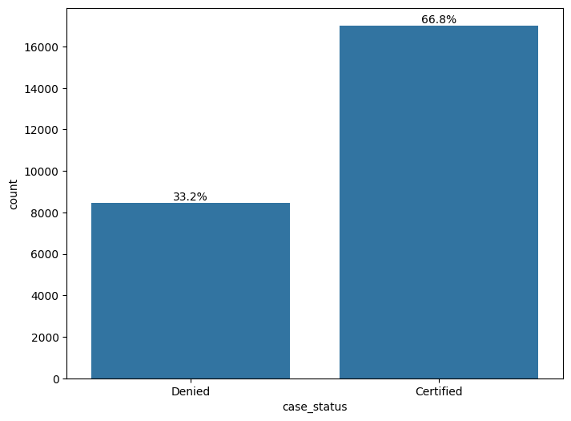

```python
countplot('case_status')
```

observations: .The employees of Asian contintent has highest visas applications,followed by Europe. .The Employeers who pursued Bachelors degree has highest visa apllications ,followed by Masters. .Employers with job Experience have highest visas applications,alos employeers who doesnot require training applied for the most .Employers who intended to work for Northeast region have more visas applications,followed by south . .Employers with full work time,got highest visas issued. .The visas certified are 67% whereas denial is 33%

Bivariate Analysis

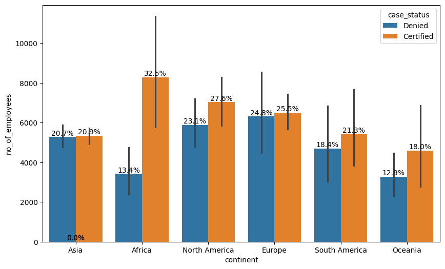

```
continent      case_status
Africa         Certified      8276.478589
               Denied         3416.746753
Asia           Certified      5334.881856
               Denied         5275.870747
Europe         Certified      6504.199527
               Denied         6308.806452
North America  Certified      7032.836524
               Denied         5882.998406
Oceania        Certified      4590.532787
               Denied         3274.200000
South America  Certified      5420.172414
               Denied         4697.846797
Name: no_of_employees, dtype: float64
```

```python
plt.figure(figsize=(10,6))
ax=sns.barplot(x='continent',y='no_of_employees',data=df,hue='case_status')
total=len(df['continent'])

for p in ax.patches:
    label="{:.1f}%".format(100*p.get_height()/total)
    x=p.get_x() + p.get_width()/2
    y=p.get_height()

    ax.annotate(
        label,
        (x,y),
        ha='center',
        va='center',
        size=10,
        xytext=(0,5),
        textcoords='offset points')
plt.show()
df.groupby(['continent','case_status'])['no_of_employees'].mean()
```

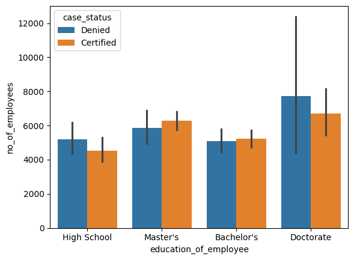

```
education_of_employee  case_status
Doctorate              Denied         7711.778571
                       Certified      6696.279289
Master's               Certified      6275.427195
                       Denied         5849.594463
Bachelor's             Certified      5214.125491
High School            Denied         5184.311170
Bachelor's             Denied         5087.545125
High School            Certified      4541.660653
Name: no_of_employees, dtype: float64
```

```python
sns.barplot(x='education_of_employee',y='no_of_employees',data=df,hue='case_status')
plt.show()
df.groupby(['education_of_employee','case_status'])['no_of_employees'].mean().sort_values(ascending=False)
```

observations: .The average number of employers who pursued Doctrate has highest visa certified,followed by Masters.

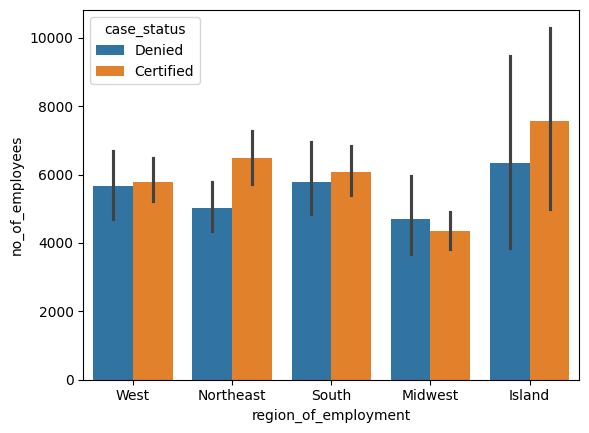

```
region_of_employment  case_status
Island                Certified      7569.438053
Northeast             Certified      6495.680292
Island                Denied         6350.503356
South                 Certified      6073.791166
                      Denied         5795.426806
West                  Certified      5792.131707
                      Denied         5654.621078
Northeast             Denied         5025.242788
Midwest               Denied         4709.100569
                      Certified      4342.471257
Name: no_of_employees, dtype: float64
```

```python
sns.barplot(x='region_of_employment',y='no_of_employees',data=df,hue='case_status')
plt.show()
df.groupby(['region_of_employment','case_status'])['no_of_employees'].mean().sort_values(ascending=False)
```

observations: The average no of employees who intend to work in Island got highest visa approved,followed by NorthEast

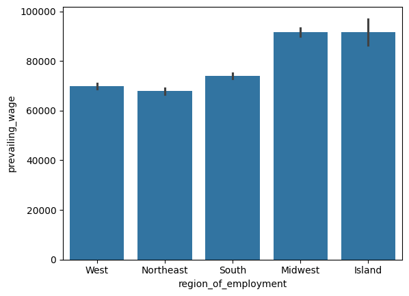

```
region_of_employment
Island       91712.750760
Midwest      91696.741794
South        74040.545216
West         69832.628698
Northeast    67872.662819
Name: prevailing_wage, dtype: float64
```

```python
sns.barplot(x='region_of_employment',y='prevailing_wage',data=df)
plt.show()
df.groupby(['region_of_employment'])['prevailing_wage'].mean().sort_values(ascending=False)
```

observations: .The prevailig wages are highest in Island,followed by Midwest.

```python
def bivariate(cols):
    plt.figure(figsize=(8,6))
    ax=sns.countplot(x=cols,hue='case_status',data=df)
    total=len(df[cols])
    for p in ax.patches:
        label="{:.1f}%".format(100*p.get_height()/total)

        x=p.get_x()+p.get_width()/2
        y=p.get_height()

        ax.annotate(
            label,
            (x,y),
            size=10,
            ha='center',
            va='center',
            xytext=(0,5),
            textcoords="offset points"
        )
    plt.show()
```

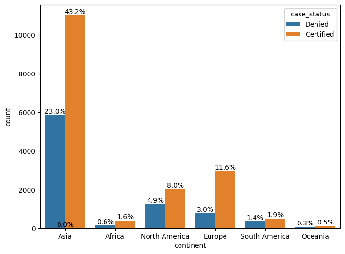

```python
bivariate('continent')
```

observations: .Asia has highest number of visa approvals,followed by europe

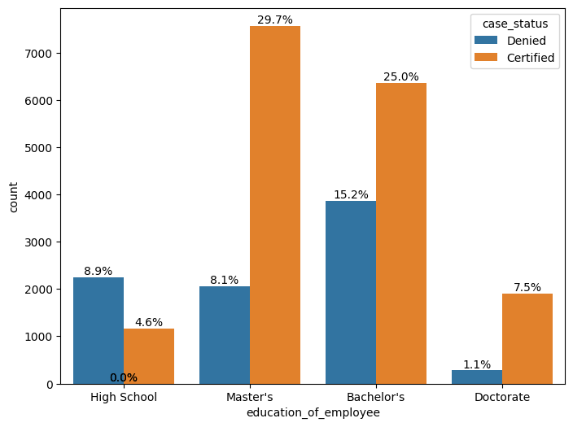

```python
bivariate('education_of_employee')
```

observations: .Employees who pursued Master have highest visas certified ,followed by Bachelors .No of visa denials are highest for employers who pursued Bachelors

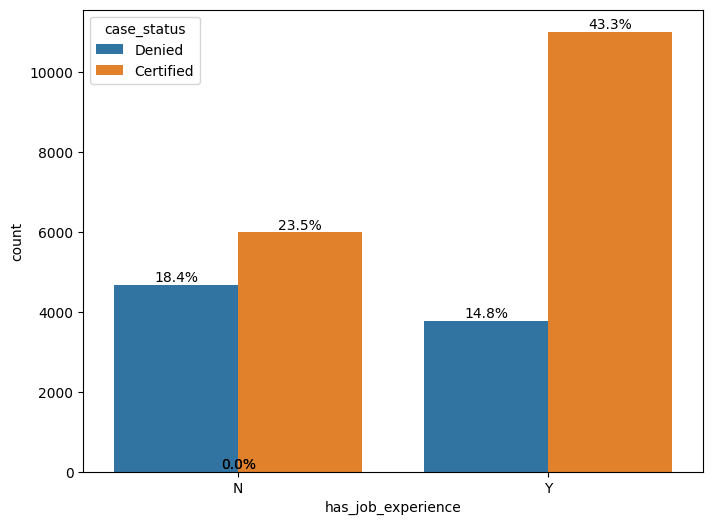

```python
bivariate('has_job_experience')
```

observations: .The percentage of employees who has job expeience have more visas certified

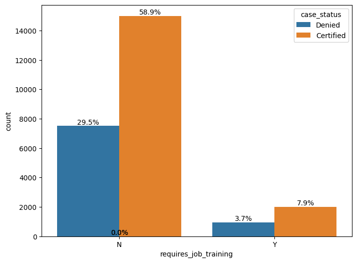

```python
bivariate('requires_job_training')
```

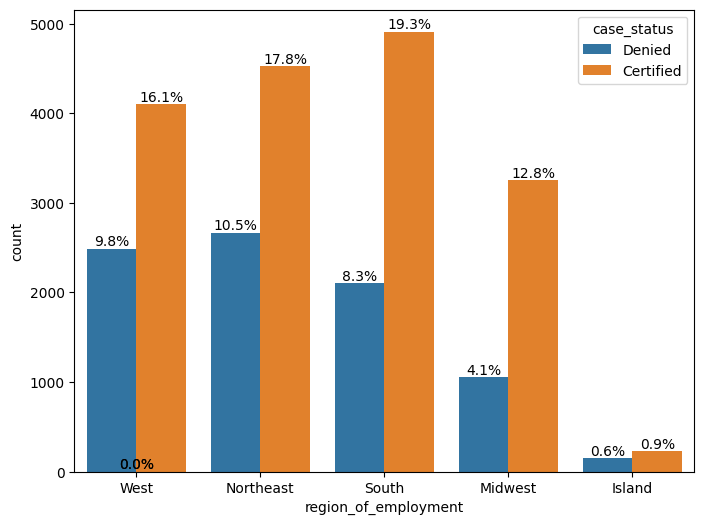

```python
bivariate('region_of_employment')
```

The employees who intend to work in south got highest visa approvals,followed by Northeast.

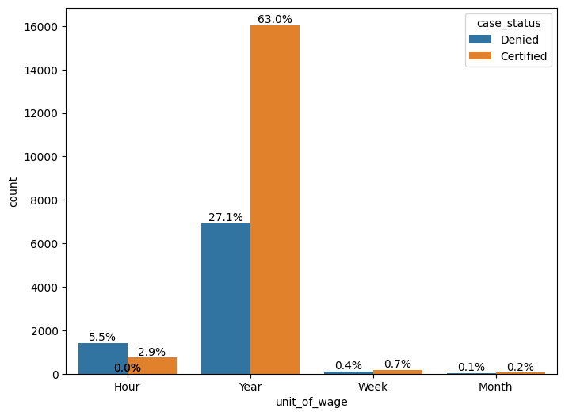

```python
bivariate('unit_of_wage')
```

observation:Hourly waged applicants are more likely to get denied while yearly are more likley to get certified

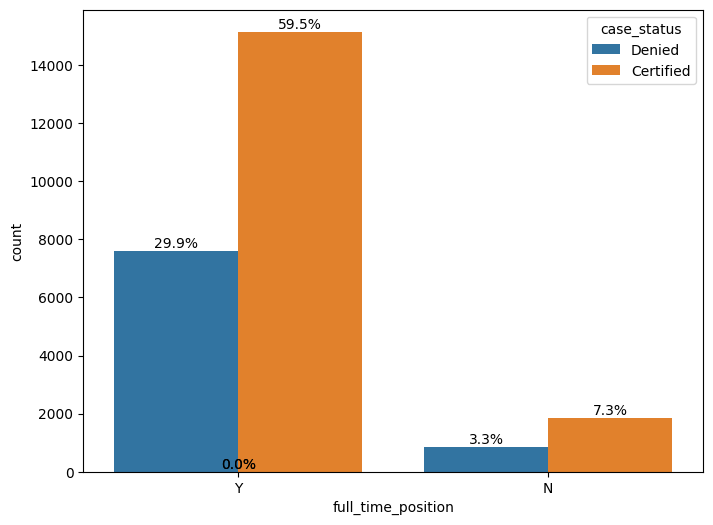

```python
bivariate('full_time_position')
```

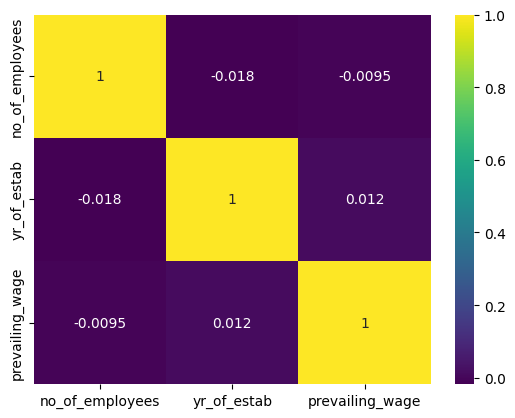

```python
num_cols=df.select_dtypes(include=np.number).columns.tolist()
df1=df[num_cols]
sns.heatmap(df1.corr(),annot=True,cmap='viridis')
plt.show()
```

observations: we cannot see any correlation between the numerical variables

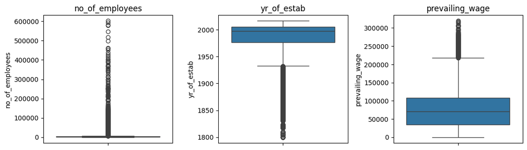

```python
# outlier detection using boxplot
numeric_columns = df.select_dtypes(include=np.number).columns.tolist()


plt.figure(figsize=(15, 12))

for i, variable in enumerate(numeric_columns):
    plt.subplot(4, 4, i + 1)
    sns.boxplot(df[variable])
    plt.tight_layout()
    plt.title(variable)

plt.show()
```

Although there are outliers, we will keep them as they have a valuable input

Feature Engineering

```python
#explicitly mapping target variable,Denied to 0,certified to 1
df['case_status']=df['case_status'].map({'Denied':0,'Certified':1})
```

```python
df.head()
```

|  | continent | education_of_employee | has_job_experience | requires_job_training | no_of_employees | yr_of_estab | region_of_employment | prevailing_wage | unit_of_wage | full_time_position | case_status |
| --- | --- | --- | --- | --- | --- | --- | --- | --- | --- | --- | --- |
| 0 | Asia | High School | N | N | 14513 | 2007 | West | 592.2029 | Hour | Y | 0 |
| 1 | Asia | Master's | Y | N | 2412 | 2002 | Northeast | 83425.6500 | Year | Y | 1 |
| 2 | Asia | Bachelor's | N | Y | 44444 | 2008 | West | 122996.8600 | Year | Y | 0 |
| 3 | Asia | Bachelor's | N | N | 98 | 1897 | West | 83434.0300 | Year | Y | 0 |
| 4 | Africa | Master's | Y | N | 1082 | 2005 | South | 149907.3900 | Year | Y | 1 |

```python
#Splitting Dataset to train set and test set
X=df.drop('case_status',axis=1)
y=df['case_status']
X.shape
```

```
(25480, 10)
```

```python
from sklearn.model_selection import train_test_split
X_train,X_test,y_train,y_test=train_test_split(X,y,test_size=0.30,random_state=42)
```

```python
#converting categorical data to numerical data
X_train=pd.get_dummies(X_train,columns=X_train.select_dtypes(include=['object','category']).columns.tolist(),drop_first=True)
X_test=pd.get_dummies(X_test,columns=X_test.select_dtypes(include=['object','category']).columns.tolist(),drop_first=True)
```

```python
#explicitly mapping true to 1,false to 0
bool_train=X_train.select_dtypes(include='bool').columns.tolist()
bool_test=X_test.select_dtypes(include='bool').columns.tolist()
for cols in bool_train:
    X_train[cols]=X_train[cols].map({True:1,False:0})
for cols in bool_test:
    X_test[cols]=X_test[cols].map({True:1,False:0})
```

```python
print("no of entries in train data",X_train.shape[0])
print("no of entries in test data",X_test.shape[0])
print("Percentage of classes in training set:")
print(y_train.value_counts(normalize=True))
print("Percentage of classes in test set:")
print(y_test.value_counts(normalize=True))
```

```
no of entries in train data 17836
no of entries in test data 7644
Percentage of classes in training set:
case_status
1    0.667134
0    0.332866
Name: proportion, dtype: float64
Percentage of classes in test set:
case_status
1    0.669676
0    0.330324
Name: proportion, dtype: float64
```

Model Evaluation criterion

```python
#function to evaluate metrics
from sklearn.metrics import accuracy_score,recall_score,precision_score,f1_score
def metrics_evaluation(model,predictors,target):
    #predicting values of  data
    y_pred=model.predict(predictors)
    #metrics evaluation
    f1=f1_score(target,y_pred)
    recall=recall_score(target,y_pred)
    precision=precision_score(target,y_pred)
    accuracy=accuracy_score(target,y_pred)

    perf=pd.DataFrame({
        'Accuracy':accuracy,
        'Precision':precision,
        'Recall': recall,
        'f1_score':f1},index=[0])
    return perf
```

```python
from sklearn.metrics import confusion_matrix
#function for confusion matrix
def confusion_mat(model,predictors,target):
    #predicting values of data
    y_pred=model.predict(predictors)

    #confusion matrix
    cm=confusion_matrix(target,y_pred)

    labels=np.asarray(
        [
            ["{0:0.0f}".format(item) + "\n{0:.2%}".format(item / cm.flatten().sum())]
            for item in cm.flatten()
        ]
    ).reshape(2,2)
    plt.figure(figsize=(6,4))
    sns.heatmap(cm,annot=labels,fmt="")
    plt.xlabel("Predicted values")
    plt.ylabel("True values")
    plt.show()
```

Building Model using Decision Tree

```python
from sklearn.tree import DecisionTreeClassifier
dt=DecisionTreeClassifier(random_state=42)
dt.fit(X_train,y_train)
```

```
DecisionTreeClassifier(random_state=42)
```

```python
dt_train_perf=metrics_evaluation(dt,X_train,y_train)
dt_train_perf
```

|  | Accuracy | Precision | Recall | f1_score |
| --- | --- | --- | --- | --- |
| 0 | 1.0 | 1.0 | 1.0 | 1.0 |

```python
dt_test_perf=metrics_evaluation(dt,X_test,y_test)
dt_test_perf
```

|  | Accuracy | Precision | Recall | f1_score |
| --- | --- | --- | --- | --- |
| 0 | 0.660911 | 0.750248 | 0.739988 | 0.745083 |

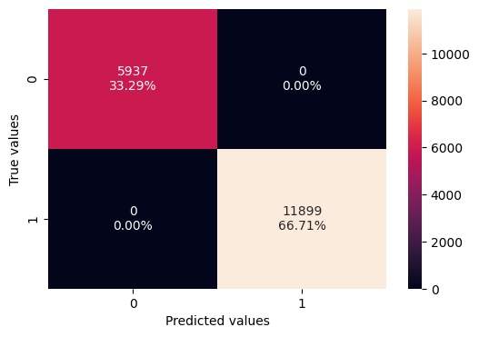

```python
confusion_mat(dt,X_train,y_train)
```

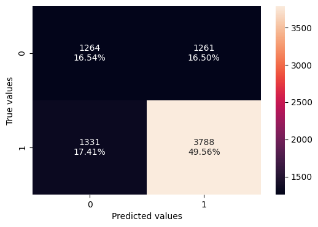

```python
confusion_mat(dt,X_test,y_test)
```

observations: .The model has claasified training data 100%,but it under performed on testing data,implying overfitting

Decision Tree model with HyperParameter Tuning

```python
#hyper parameter tunin using GridSearchCV
from sklearn.model_selection import GridSearchCV
from sklearn.metrics import make_scorer

dt_gs=DecisionTreeClassifier(random_state=42,class_weight='balanced')

parameters = {
    "max_depth": np.arange(10, 30, 5),
    "min_samples_leaf": [3, 5, 7],
    "max_leaf_nodes": [2, 3, 5],
    "min_impurity_decrease": [0.0001, 0.001],
}
# Type of scoring used to compare parameter combinations
f1_scorer=make_scorer(f1_score)

grid_dt=GridSearchCV(dt_gs,parameters,scoring=f1_scorer,cv=5)

#fit the model
grid_dt.fit(X_train,y_train)

print("best parameters are",grid_dt.best_params_)

#fitting the data to best-estimator
dt_gs=grid_dt.best_estimator_
dt_gs.fit(X_train,y_train)
```

```
best parameters are {'max_depth': np.int64(10), 'max_leaf_nodes': 2, 'min_impurity_decrease': 0.0001, 'min_samples_leaf': 3}
```

```
DecisionTreeClassifier(class_weight='balanced', max_depth=np.int64(10),
                       max_leaf_nodes=2, min_impurity_decrease=0.0001,
                       min_samples_leaf=3, random_state=42)
```

```python
dt_gd_train=metrics_evaluation(dt_gs,X_train,y_train)
dt_gd_train
```

|  | Accuracy | Precision | Recall | f1_score |
| --- | --- | --- | --- | --- |
| 0 | 0.710697 | 0.718416 | 0.931423 | 0.811169 |

```python
dt_gd_test=metrics_evaluation(dt_gs,X_test,y_test)
dt_gd_test
```

|  | Accuracy | Precision | Recall | f1_score |
| --- | --- | --- | --- | --- |
| 0 | 0.710884 | 0.719282 | 0.932018 | 0.811947 |

observations: .The performance of test and training data are similar,the model is not overfitting. .High recall indicates that the model is very good at identifying positive cases. .the F1 score is relatively high, it suggests a good trade-off between precision and recall

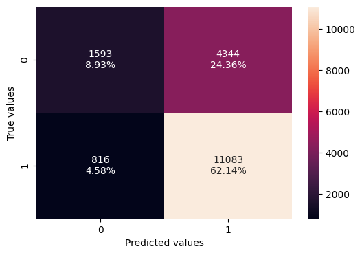

```python
confusion_mat(dt_gs,X_train,y_train)
```

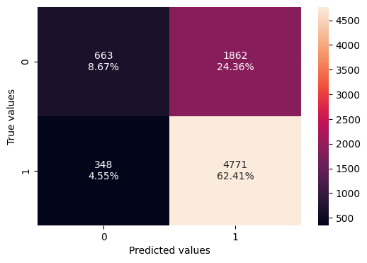

```python
confusion_mat(dt_gs,X_test,y_test)
```

Modelling using Bagging Classifier and Hyper parameter Tuning

```python
from sklearn.tree import DecisionTreeClassifier
from sklearn.ensemble import BaggingClassifier

#Instantiate base model
#base_model=DecisionTreeClassifier(class_weight='balanced',random_state=42)

#Instantiate Bagging classifier
#Bagging_model=BaggingClassifier(estimator=base_model,n_estimators=100,random_state=42,n_jobs=-1)
Bagging_model=BaggingClassifier(random_state=42)

Bagging_model.fit(X_train,y_train)
```

```
BaggingClassifier(random_state=42)
```

```python
Bc_train=metrics_evaluation(Bagging_model,X_train,y_train)
Bc_train
```

|  | Accuracy | Precision | Recall | f1_score |
| --- | --- | --- | --- | --- |
| 0 | 0.984582 | 0.990961 | 0.985881 | 0.988415 |

```python
Bc_test=metrics_evaluation(Bagging_model,X_test,y_test)
Bc_test
```

|  | Accuracy | Precision | Recall | f1_score |
| --- | --- | --- | --- | --- |
| 0 | 0.690999 | 0.770453 | 0.767142 | 0.768794 |

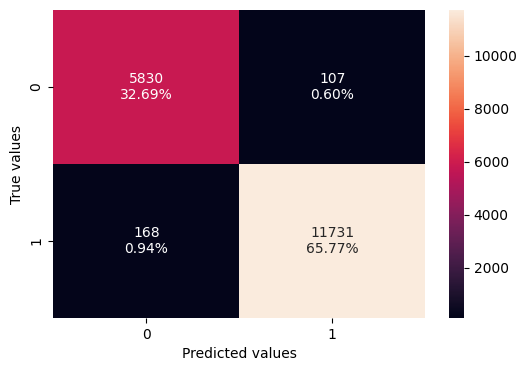

```python
confusion_mat(Bagging_model,X_train,y_train)
```

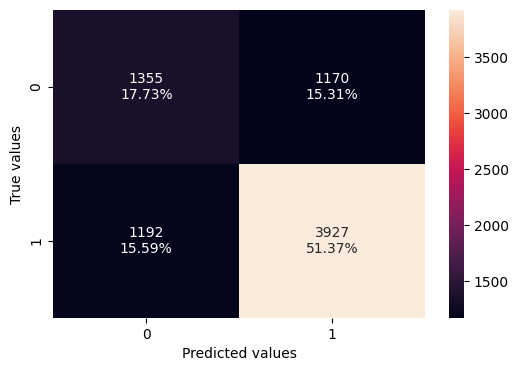

```python
confusion_mat(Bagging_model,X_test,y_test)
```

observations:The model performed very well on traning data,whereas under performed on test data.Thus, the model is overfitting

```python
#Bagging Classifier using GridSerachCV
from sklearn.model_selection import GridSearchCV
from sklearn.tree import DecisionTreeClassifier
from sklearn.metrics import make_scorer

base_model=DecisionTreeClassifier(random_state=42, class_weight='balanced')
Bg_gs=BaggingClassifier(estimator=base_model,random_state=42)
#Bg_gs=BaggingClassifier(random_state=42)

parameters = {
    "max_samples": [0.7, 0.8, 0.9],
    "max_features": [0.7, 0.8, 0.9],
    "n_estimators": np.arange(90, 120, 10)
}

#f1_score=make_scorer(f1_score)

Grid_bs=GridSearchCV(Bg_gs,parameters,cv=3,scoring='f1')

#fit the model
Grid_bs.fit(X_train,y_train)

print("best params are",Grid_bs.best_params_)

#fit data to best estimator
Bg_gs=Grid_bs.best_estimator_
Bg_gs.fit(X_train,y_train)
```

```
best params are {'max_features': 0.7, 'max_samples': 0.7, 'n_estimators': np.int64(110)}
```

```
BaggingClassifier(estimator=DecisionTreeClassifier(class_weight='balanced',
                                                   random_state=42),
                  max_features=0.7, max_samples=0.7, n_estimators=np.int64(110),
                  random_state=42)
```

```python
y_pred=Bg_gs.predict(X_train)
#metrics evaluation
f1=f1_score(y_train,y_pred, average='weighted')
recall=recall_score(y_train,y_pred,average='weighted')
precision=precision_score(y_train,y_pred,average='weighted')
accuracy=accuracy_score(y_train,y_pred)

Bg_gs_train=pd.DataFrame({
        'Accuracy':accuracy,
        'Precision':precision,
        'Recall': recall,
        'f1_score':f1},index=[0])
Bg_gs_train
```

|  | Accuracy | Precision | Recall | f1_score |
| --- | --- | --- | --- | --- |
| 0 | 0.997365 | 0.997371 | 0.997365 | 0.997363 |

```python
y_pred=Bg_gs.predict(X_test)
#metrics evaluation
f1=f1_score(y_test,y_pred, average='weighted')
recall=recall_score(y_test,y_pred,average='weighted')
precision=precision_score(y_test,y_pred,average='weighted')
accuracy=accuracy_score(y_test,y_pred)

Bg_gs_test=pd.DataFrame({
        'Accuracy':accuracy,
        'Precision':precision,
        'Recall': recall,
        'f1_score':f1},index=[0])
Bg_gs_test
```

|  | Accuracy | Precision | Recall | f1_score |
| --- | --- | --- | --- | --- |
| 0 | 0.732208 | 0.719891 | 0.732208 | 0.710971 |

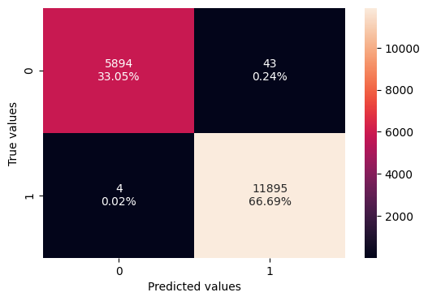

```python
confusion_mat(Bg_gs,X_train,y_train)
```

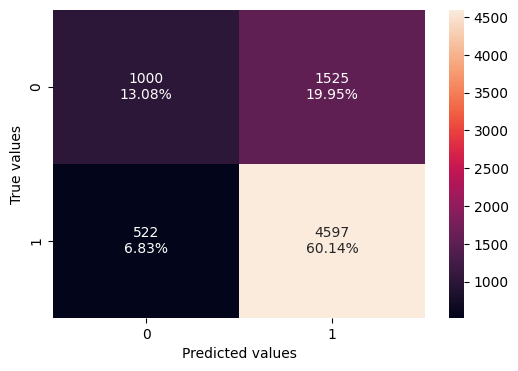

```python
confusion_mat(Bg_gs,X_test,y_test)
```

observations:the bagging calssifered is still overfitting even after tuning

Modelling using RandomForest and HyperParameter Tuning

```python
from sklearn.ensemble import RandomForestClassifier
rc=RandomForestClassifier(random_state=42,class_weight='balanced')
rc.fit(X_train,y_train)
```

```
RandomForestClassifier(class_weight='balanced', random_state=42)
```

```python
rc_train=metrics_evaluation(rc,X_train,y_train)
rc_train
```

|  | Accuracy | Precision | Recall | f1_score |
| --- | --- | --- | --- | --- |
| 0 | 1.0 | 1.0 | 1.0 | 1.0 |

```python
rc_test=metrics_evaluation(rc,X_test,y_test)
rc_test
```

|  | Accuracy | Precision | Recall | f1_score |
| --- | --- | --- | --- | --- |
| 0 | 0.724359 | 0.767306 | 0.844501 | 0.804055 |

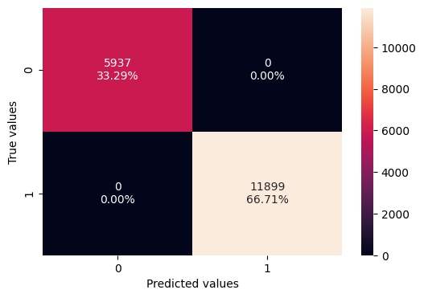

```python
confusion_mat(rc,X_train,y_train)
```

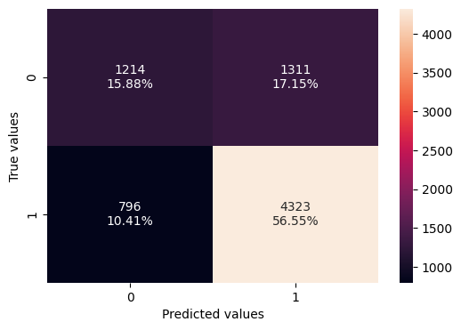

```python
confusion_mat(rc,X_test,y_test)
```

observations:The model is overffitting

Hyperparameter Tuning - Random Forest

```python
from sklearn.model_selection import GridSearchCV
from sklearn.ensemble import RandomForestClassifier
from sklearn.metrics import make_scorer
import warnings
warnings.filterwarnings("ignore")


rc_gs=RandomForestClassifier(random_state=42,oob_score=True, bootstrap=True)
parameters={
    "max_depth": list(np.arange(5, 15, 5)),
    "max_features": ["sqrt", "log2"],
    "min_samples_split": [3, 5, 7],
    "n_estimators": np.arange(10, 40, 10),
}
f1=make_scorer(f1_score)
gs_obj=GridSearchCV(rc_gs,parameters,cv=5,scoring=f1)

gs_obj.fit(X_train,y_train)

print("the best parameters are",gs_obj.best_params_)

rc_gs=gs_obj.best_estimator_
rc_gs.fit(X_train,y_train)
```

```
the best parameters are {'max_depth': np.int64(10), 'max_features': 'sqrt', 'min_samples_split': 7, 'n_estimators': np.int64(30)}
```

```
RandomForestClassifier(max_depth=np.int64(10), min_samples_split=7,
                       n_estimators=np.int64(30), oob_score=True,
                       random_state=42)
```

```python
rc_gs_train=metrics_evaluation(rc_gs,X_train,y_train)
rc_gs_train
```

|  | Accuracy | Precision | Recall | f1_score |
| --- | --- | --- | --- | --- |
| 0 | 0.769623 | 0.784514 | 0.902597 | 0.839423 |

```python
rc_gs_test=metrics_evaluation(rc_gs,X_test,y_test)
rc_gs_test
```

|  | Accuracy | Precision | Recall | f1_score |
| --- | --- | --- | --- | --- |
| 0 | 0.746337 | 0.768128 | 0.889822 | 0.824509 |

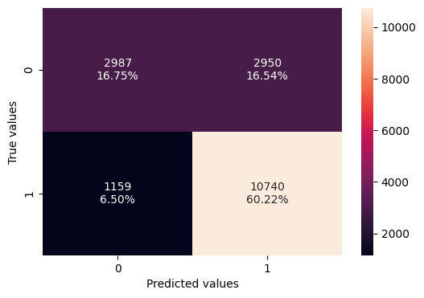

```python
confusion_mat(rc_gs,X_train,y_train)
```

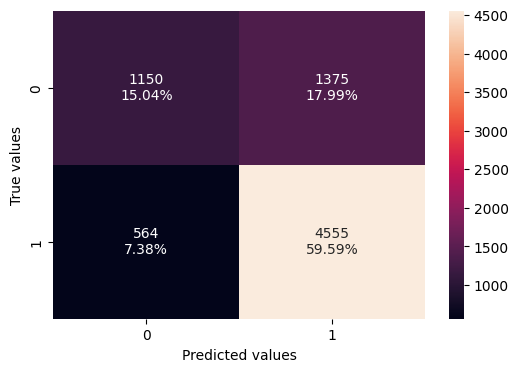

```python
confusion_mat(rc_gs,X_test,y_test)
```

After hyperparameter tuning the model performance has generalized.

Boosting - Model Building and Hyperparameter Tuning

AdaBoost Classifier

```python
from sklearn.ensemble import AdaBoostClassifier
from sklearn.tree import DecisionTreeClassifier

base_learner =DecisionTreeClassifier(random_state=42,max_depth=1)
abc=AdaBoostClassifier(estimator=base_learner,random_state=42)
abc.fit(X_train,y_train)
```

```
AdaBoostClassifier(estimator=DecisionTreeClassifier(max_depth=1,
                                                    random_state=42),
                   random_state=42)
```

```python
abc_train=metrics_evaluation(abc,X_train,y_train)
abc_train
```

|  | Accuracy | Precision | Recall | f1_score |
| --- | --- | --- | --- | --- |
| 0 | 0.734918 | 0.750297 | 0.903269 | 0.819707 |

```python
abc_test=metrics_evaluation(abc,X_test,y_test)
abc_test
```

|  | Accuracy | Precision | Recall | f1_score |
| --- | --- | --- | --- | --- |
| 0 | 0.735217 | 0.750121 | 0.906622 | 0.82098 |

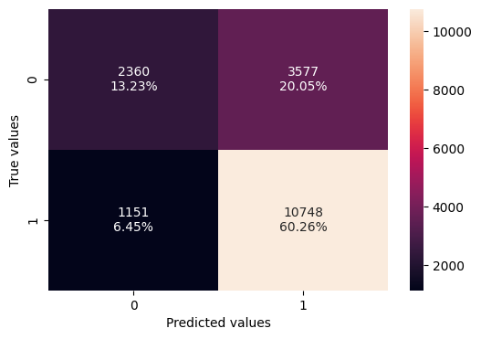

```python
confusion_mat(abc,X_train,y_train)
```

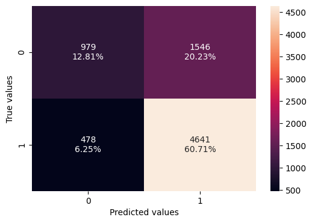

```python
confusion_mat(abc,X_test,y_test)
```

The model has generalised well

Adaboost-HyperParameter Tuning

```python
from sklearn.model_selection import GridSearchCV
from sklearn.ensemble import AdaBoostClassifier
from sklearn.metrics import make_scorer

abc_gs=AdaBoostClassifier(random_state=42)

# Grid of parameters to choose from
parameters = {
    "n_estimators": np.arange(50,110,25),
    "learning_rate": [0.01,0.1,0.05],
    "estimator": [
        DecisionTreeClassifier(max_depth=2, random_state=1),
        DecisionTreeClassifier(max_depth=3, random_state=1),
    ],
}

f1=make_scorer(f1_score)
gs_obj=GridSearchCV(abc_gs,parameters,cv=5,scoring=f1)
gs_obj.fit(X_train,y_train)
print("the best parameters are:",gs_obj.best_params_)
#fit data to best estimator
abc_gs=gs_obj.best_estimator_
abc_gs.fit(X_train,y_train)
```

```
the best parameters are: {'estimator': DecisionTreeClassifier(max_depth=3, random_state=1), 'learning_rate': 0.1, 'n_estimators': np.int64(75)}
```

```
AdaBoostClassifier(estimator=DecisionTreeClassifier(max_depth=3,
                                                    random_state=1),
                   learning_rate=0.1, n_estimators=np.int64(75),
                   random_state=42)
```

```python
abc_gs_train=metrics_evaluation(abc_gs,X_train,y_train)
abc_gs_train
```

|  | Accuracy | Precision | Recall | f1_score |
| --- | --- | --- | --- | --- |
| 0 | 0.749383 | 0.777139 | 0.875368 | 0.823334 |

```python
abc_gs_test=metrics_evaluation(abc_gs,X_test,y_test)
abc_gs_test
```

|  | Accuracy | Precision | Recall | f1_score |
| --- | --- | --- | --- | --- |
| 0 | 0.749608 | 0.776531 | 0.879078 | 0.824629 |

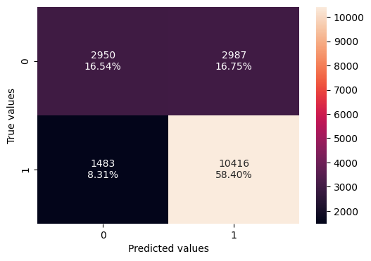

```python
confusion_mat(abc_gs,X_train,y_train)
```

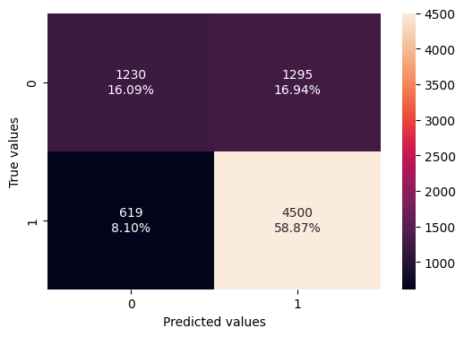

```python
confusion_mat(abc_gs,X_test,y_test)
```

.The model has generalised well

Gradient Boosting Classifier-Modelling and HyperParameter Tuning

```python
from sklearn.ensemble import GradientBoostingClassifier
from sklearn.tree import DecisionTreeClassifier

gbc=GradientBoostingClassifier(random_state=42)
gbc.fit(X_train,y_train)
```

```
GradientBoostingClassifier(random_state=42)
```

```python
gbc_train=metrics_evaluation(gbc,X_train,y_train)
gbc_train
```

|  | Accuracy | Precision | Recall | f1_score |
| --- | --- | --- | --- | --- |
| 0 | 0.756728 | 0.784853 | 0.875284 | 0.827605 |

```python
gbc_test=metrics_evaluation(gbc,X_test,y_test)
gbc_test
```

|  | Accuracy | Precision | Recall | f1_score |
| --- | --- | --- | --- | --- |
| 0 | 0.750916 | 0.778259 | 0.878297 | 0.825257 |

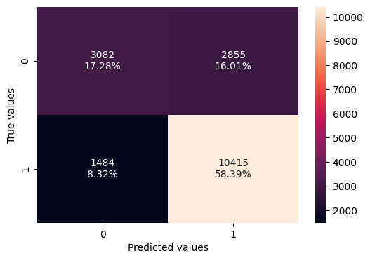

```python
confusion_mat(gbc,X_train,y_train)
```

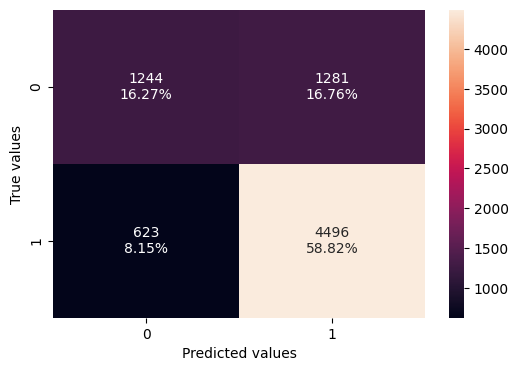

```python
confusion_mat(gbc,X_test,y_test)
```

observations:The model has generalised well

```python
from sklearn.ensemble import GradientBoostingClassifier
from sklearn.metrics import make_scorer
from sklearn.model_selection import GridSearchCV

gbc_gs=GradientBoostingClassifier(
    init=AdaBoostClassifier(random_state=1), random_state=1
)
parameters={
    "init": [AdaBoostClassifier(random_state=1),DecisionTreeClassifier(random_state=1)],
    "n_estimators": np.arange(50,110,25),
    "learning_rate": [0.01,0.1,0.05],
    "subsample":[0.7,0.9],
    "max_features":[0.5,0.7,1],
}
f1=make_scorer(f1_score)
gs_obj=GridSearchCV(gbc_gs,parameters,cv=5,scoring=f1)
gs_obj.fit(X_train,y_train)

print("the best parameters are:",gs_obj.best_params_)

gbc_gs=gs_obj.best_estimator_
gbc_gs.fit(X_train,y_train)
```

```
the best parameters are: {'init': AdaBoostClassifier(random_state=1), 'learning_rate': 0.1, 'max_features': 0.7, 'n_estimators': np.int64(50), 'subsample': 0.9}
```

```
GradientBoostingClassifier(init=AdaBoostClassifier(random_state=1),
                           max_features=0.7, n_estimators=np.int64(50),
                           random_state=1, subsample=0.9)
```

```python
gbc_gs_train=metrics_evaluation(gbc_gs,X_train,y_train)
gbc_gs_train
```

|  | Accuracy | Precision | Recall | f1_score |
| --- | --- | --- | --- | --- |
| 0 | 0.750673 | 0.770628 | 0.891672 | 0.826743 |

```python
gbc_gs_test=metrics_evaluation(gbc_gs,X_test,y_test)
gbc_gs_test
```

|  | Accuracy | Precision | Recall | f1_score |
| --- | --- | --- | --- | --- |
| 0 | 0.74529 | 0.766555 | 0.890994 | 0.824103 |

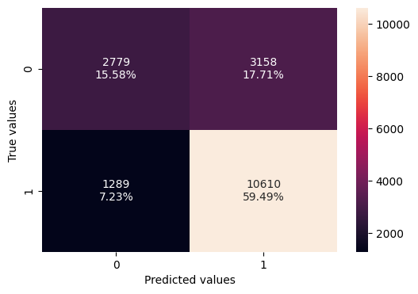

```python
confusion_mat(gbc_gs,X_train,y_train)
```

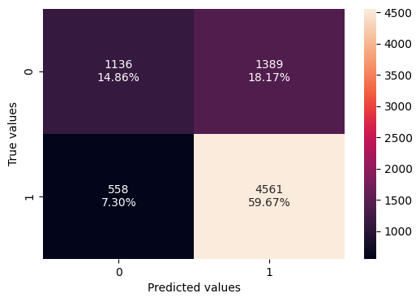

```python
confusion_mat(gbc_gs,X_test,y_test)
```

XGBoost Classifier-Modelling and HyperParameter Tuning

```python
!pip install xgboost
import xgboost as xgb


xgb1=xgb.XGBClassifier(random_state=42,eval_metric='logloss')
xgb1.fit(X_train,y_train)
```

```
XGBClassifier(base_score=None, booster=None, callbacks=None,
              colsample_bylevel=None, colsample_bynode=None,
              colsample_bytree=None, device=None, early_stopping_rounds=None,
              enable_categorical=False, eval_metric='logloss',
              feature_types=None, gamma=None, grow_policy=None,
              importance_type=None, interaction_constraints=None,
              learning_rate=None, max_bin=None, max_cat_threshold=None,
              max_cat_to_onehot=None, max_delta_step=None, max_depth=None,
              max_leaves=None, min_child_weight=None, missing=nan,
              monotone_constraints=None, multi_strategy=None, n_estimators=None,
              n_jobs=None, num_parallel_tree=None, random_state=42, ...)
```

```python
xgb_train=metrics_evaluation(xgb1,X_train,y_train)
xgb_train
```

|  | Accuracy | Precision | Recall | f1_score |
| --- | --- | --- | --- | --- |
| 0 | 0.843519 | 0.846364 | 0.935205 | 0.888569 |

```python
xgb_test=metrics_evaluation(xgb1,X_test,y_test)
xgb_test
```

|  | Accuracy | Precision | Recall | f1_score |
| --- | --- | --- | --- | --- |
| 0 | 0.728676 | 0.766684 | 0.85505 | 0.80846 |

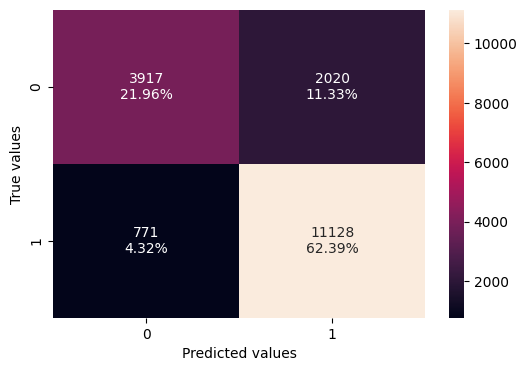

```python
confusion_mat(xgb1,X_train,y_train)
```

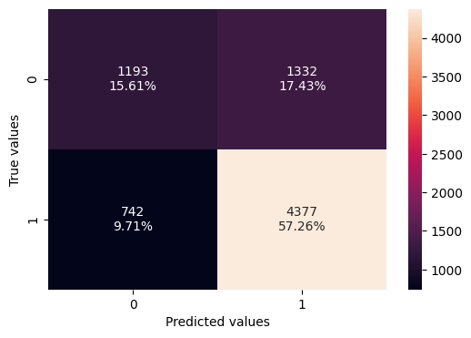

```python
confusion_mat(xgb1,X_test,y_test)
```

```python
from sklearn.metrics import make_scorer
from sklearn.model_selection import GridSearchCV

xgb_gs=xgb.XGBClassifier(random_state=42,eval_metric='logloss')
parameters={
    "n_estimators": np.arange(150, 250, 50),
    "scale_pos_weight": [1, 2],
    "subsample": [0.9, 1],
    "learning_rate": np.arange(0.1, 0.21, 0.1),
    "gamma": [3, 5],
    "colsample_bytree": [0.8, 0.9],
    "colsample_bylevel": [ 0.9, 1],
}
f1=make_scorer(f1_score)
gs_obj=GridSearchCV(xgb_gs,parameters,cv=5,scoring=f1)
gs_obj.fit(X_train,y_train)

print("the best parametrs are",gs_obj.best_params_)
xgb_gs=gs_obj.best_estimator_
xgb_gs.fit(X_train,y_train)
```

```
the best parametrs are {'colsample_bylevel': 0.9, 'colsample_bytree': 0.8, 'gamma': 3, 'learning_rate': np.float64(0.1), 'n_estimators': np.int64(150), 'scale_pos_weight': 1, 'subsample': 1}
```

```
XGBClassifier(base_score=None, booster=None, callbacks=None,
              colsample_bylevel=0.9, colsample_bynode=None,
              colsample_bytree=0.8, device=None, early_stopping_rounds=None,
              enable_categorical=False, eval_metric='logloss',
              feature_types=None, gamma=3, grow_policy=None,
              importance_type=None, interaction_constraints=None,
              learning_rate=np.float64(0.1), max_bin=None,
              max_cat_threshold=None, max_cat_to_onehot=None,
              max_delta_step=None, max_depth=None, max_leaves=None,
              min_child_weight=None, missing=nan, monotone_constraints=None,
              multi_strategy=None, n_estimators=np.int64(150), n_jobs=None,
              num_parallel_tree=None, random_state=42, ...)
```

```python
xgb_gs_train=metrics_evaluation(xgb_gs,X_train,y_train)
xgb_gs_train
```

|  | Accuracy | Precision | Recall | f1_score |
| --- | --- | --- | --- | --- |
| 0 | 0.760933 | 0.787484 | 0.878813 | 0.830646 |

```python
xgb_gs_test=metrics_evaluation(xgb_gs,X_test,y_test)
xgb_gs_test
```

|  | Accuracy | Precision | Recall | f1_score |
| --- | --- | --- | --- | --- |
| 0 | 0.751701 | 0.779552 | 0.87732 | 0.825551 |

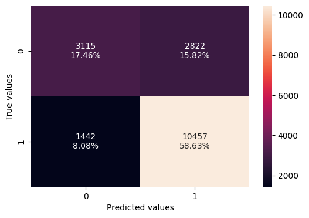

```python
confusion_mat(xgb_gs,X_train,y_train)
```

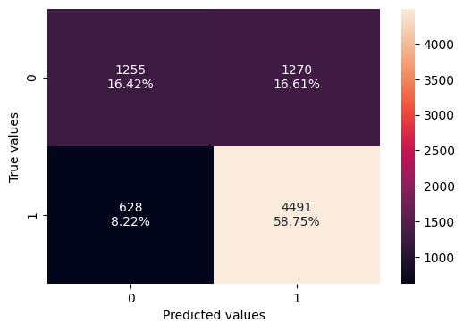

```python
confusion_mat(xgb_gs,X_test,y_test)
```

Stacking Classifier

```python
from sklearn.ensemble import StackingClassifier
estimators=[
    ("AdaBoost", abc_gs),
    ("Gradient Boosting", gbc_gs),
    ("Random Forest", rc_gs),
]
final_estimator=xgb_gs
stackc=StackingClassifier(estimators=estimators,final_estimator=final_estimator)
stackc.fit(X_train,y_train)
```

```
StackingClassifier(estimators=[('AdaBoost',
                                AdaBoostClassifier(estimator=DecisionTreeClassifier(max_depth=3,
                                                                                    random_state=1),
                                                   learning_rate=0.1,
                                                   n_estimators=np.int64(75),
                                                   random_state=42)),
                               ('Gradient Boosting',
                                GradientBoostingClassifier(init=AdaBoostClassifier(random_state=1),
                                                           random_state=1)),
                               ('Random Forest',
                                RandomForestClassifier(max_depth=np.int64(10)...
                                                 importance_type=None,
                                                 interaction_constraints=None,
                                                 learning_rate=np.float64(0.1),
                                                 max_bin=None,
                                                 max_cat_threshold=None,
                                                 max_cat_to_onehot=None,
                                                 max_delta_step=None,
                                                 max_depth=None,
                                                 max_leaves=None,
                                                 min_child_weight=None,
                                                 missing=nan,
                                                 monotone_constraints=None,
                                                 multi_strategy=None,
                                                 n_estimators=np.int64(150),
                                                 n_jobs=None,
                                                 num_parallel_tree=None,
                                                 random_state=42, ...))
```

```python
stackc_train=metrics_evaluation(stackc,X_train,y_train)
stackc_train
```

|  | Accuracy | Precision | Recall | f1_score |
| --- | --- | --- | --- | --- |
| 0 | 0.759083 | 0.786695 | 0.876544 | 0.829193 |

```python
stackc_test=metrics_evaluation(stackc,X_test,y_test)
stackc_test
```

|  | Accuracy | Precision | Recall | f1_score |
| --- | --- | --- | --- | --- |
| 0 | 0.750785 | 0.77977 | 0.874976 | 0.824634 |

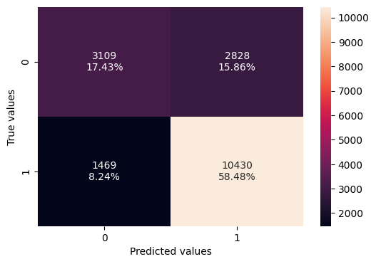

```python
confusion_mat(stackc,X_train,y_train)
```

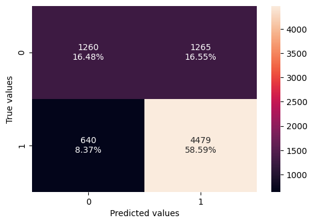

```python
confusion_mat(stackc,X_test,y_test)
```

Model Comparison and Final Model Selection

```python
# training performance comparison

models_train_comp_df = pd.concat(
    [
        dt_train_perf.T,
        dt_gd_train.T,
        Bc_train.T,
        Bg_gs_train.T,
        rc_train.T,
        rc_gs_train.T,
        abc_train.T,
        abc_gs_train.T,
        gbc_train.T,
        gbc_gs_train.T,
        xgb_train.T,
        xgb_gs_train.T,
        stackc_train.T
    ],
    axis=1,
)
models_train_comp_df.columns = [
    "Decision Tree",
    "Tuned Decision Tree",
    "Bagging Classifier",
    "Tuned Bagging Classifier",
    "Random Forest",
    "Tuned Random Forest",
    "Adaboost Classifier",
    "Tuned Adaboost Classifier",
    "Gradient Boost Classifier",
    "Tuned Gradient Boost Classifier",
    "XGBoost Classifier",
    "XGBoost Classifier Tuned",
    "Stacking Classifier",
]
print("Training performance comparison:")
models_train_comp_df
```

```
Training performance comparison:
```

|  | Decision Tree | Tuned Decision Tree | Bagging Classifier | Tuned Bagging Classifier | Random Forest | Tuned Random Forest | Adaboost Classifier | Tuned Adaboost Classifier | Gradient Boost Classifier | Tuned Gradient Boost Classifier | XGBoost Classifier | XGBoost Classifier Tuned | Stacking Classifier |
| --- | --- | --- | --- | --- | --- | --- | --- | --- | --- | --- | --- | --- | --- |
| Accuracy | 1.0 | 0.710697 | 0.984582 | 0.997365 | 1.0 | 0.769623 | 0.734918 | 0.749383 | 0.756728 | 0.750673 | 0.843519 | 0.760933 | 0.759083 |
| Precision | 1.0 | 0.718416 | 0.990961 | 0.997371 | 1.0 | 0.784514 | 0.750297 | 0.777139 | 0.784853 | 0.770628 | 0.846364 | 0.787484 | 0.786695 |
| Recall | 1.0 | 0.931423 | 0.985881 | 0.997365 | 1.0 | 0.902597 | 0.903269 | 0.875368 | 0.875284 | 0.891672 | 0.935205 | 0.878813 | 0.876544 |
| f1_score | 1.0 | 0.811169 | 0.988415 | 0.997363 | 1.0 | 0.839423 | 0.819707 | 0.823334 | 0.827605 | 0.826743 | 0.888569 | 0.830646 | 0.829193 |

```python
models_test_comp_df = pd.concat(
    [
        dt_test_perf.T,
        dt_gd_test.T,
        Bc_test.T,
        Bg_gs_test.T,
        rc_test.T,
        rc_gs_test.T,
        abc_test.T,
        abc_gs_test.T,
        gbc_test.T,
        gbc_gs_test.T,
        xgb_test.T,
        xgb_gs_test.T,
        stackc_test.T
    ],
    axis=1,
)
models_test_comp_df.columns = [
    "Decision Tree",
    "Tuned Decision Tree",
    "Bagging Classifier",
    "Tuned Bagging Classifier",
    "Random Forest",
    "Tuned Random Forest",
    "Adaboost Classifier",
    "Tuned Adaboost Classifier",
    "Gradient Boost Classifier",
    "Tuned Gradient Boost Classifier",
    "XGBoost Classifier",
    "XGBoost Classifier Tuned",
    "Stacking Classifier",
]
print("Testing performance comparison:")
models_test_comp_df
```

```
Testing performance comparison:
```

|  | Decision Tree | Tuned Decision Tree | Bagging Classifier | Tuned Bagging Classifier | Random Forest | Tuned Random Forest | Adaboost Classifier | Tuned Adaboost Classifier | Gradient Boost Classifier | Tuned Gradient Boost Classifier | XGBoost Classifier | XGBoost Classifier Tuned | Stacking Classifier |
| --- | --- | --- | --- | --- | --- | --- | --- | --- | --- | --- | --- | --- | --- |
| Accuracy | 0.660911 | 0.710884 | 0.690999 | 0.732208 | 0.724359 | 0.746337 | 0.735217 | 0.749608 | 0.750916 | 0.745290 | 0.728676 | 0.751701 | 0.750785 |
| Precision | 0.750248 | 0.719282 | 0.770453 | 0.719891 | 0.767306 | 0.768128 | 0.750121 | 0.776531 | 0.778259 | 0.766555 | 0.766684 | 0.779552 | 0.779770 |
| Recall | 0.739988 | 0.932018 | 0.767142 | 0.732208 | 0.844501 | 0.889822 | 0.906622 | 0.879078 | 0.878297 | 0.890994 | 0.855050 | 0.877320 | 0.874976 |
| f1_score | 0.745083 | 0.811947 | 0.768794 | 0.710971 | 0.804055 | 0.824509 | 0.820980 | 0.824629 | 0.825257 | 0.824103 | 0.808460 | 0.825551 | 0.824634 |

Important features of the final model

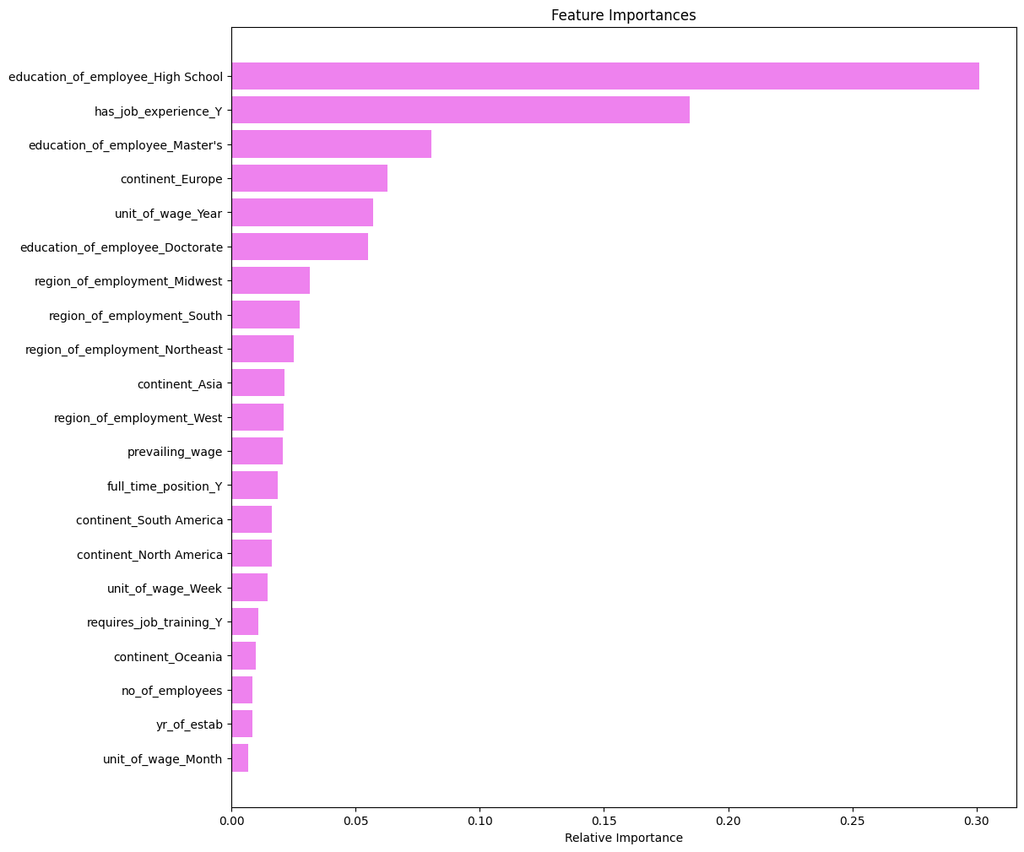

```python
feature_names = X_train.columns
importances = xgb_gs.feature_importances_
indices = np.argsort(importances)

plt.figure(figsize=(12, 12))
plt.title("Feature Importances")
plt.barh(range(len(indices)), importances[indices], color="violet", align="center")
plt.yticks(range(len(indices)), [feature_names[i] for i in indices])
plt.xlabel("Relative Importance")
plt.show()
```